# Análisis de Expresión Diferencial

Transcriptómica HTG

Aarón Marcén

2024-04-09

# Importación y Tratamiento de datos

Se importan los dataframes `counts` y `meta`, que contienen los datos curados obtenido a partir del workflow de Tratamiento y QC.

- `counts`: matriz de counts, donde sus filas son los genes y sus columnas las muestras.
- `meta`: matriz de metadatos, donde sus filas son las muestras y sus columnas variables informativas.

## Exclusión de muestras

Después de la importación de los datos, se eliminan los siguientes casos:

Las 3 muestras que se sometieron al QC original de HTG Molecular y no lo pasaron, etiquetadas en la variable Green flag como “no”. Que son:

- “3-B17-17894”
- “3-B17-26615”
- “3-B10-39759”

Las 6 muestras que no han cumplido con los criterios de aceptación impuestos en nuestro QC, que son:

- “18-C14-03618”
- “4-B16-38483-1”
- “14-B19-09150-A1”
- “4-B19-09868-B1”
- “18-B20-24791”
- “18-N20-00167-A14N”

Y por último una muestra outlier del grupo REACTIVE BRAIN INFILTRATE, que pertenece a un trío de réplicas técnicas (misma muestra secuenciada diferentes veces). En este caso las otras dos réplicas técnicas se agrupan junto con el resto de casos del grupo control y estrechamente entre ellas, como es de esperar. Mientras que la tercera réplica y outlier se distancia de todos los controles, lo que hace sospechar que se debe a que tiene una alta variabilidad técnica.

- “14-B16-38017-Normal”

## Transformar NHC y NHC_dup a variables categóricas

Se genera una nueva variable `NHCdup` para marcar los NHC de los pacientes con más de una muestra.

## Subsets de datos

Se generan diferentes subsets de los datos (counts y meta), en función de las comparaciones entre grupos experimentales, con el objetivo de hacer análisis de expresión diferencial entre los casos de estos grupos.

Estos subsets se definen de la siguiente forma:

- PCNSL vs SCNSL: `counts_PS` & `meta_PS`.
- PCNSL vs REACTIVE BRAIN INFILTRATE: `counts_PR` & `meta_PR`.
- PCNSL vs DLBCL (wo & with CNS inv): `counts_PD` & `meta_PD`.
- SCNSL vs DLBCL with CNS inv: `counts_SD` & `meta_SD`.
- DLBCL wo CNS inv vs DLBCL with CNS inv: `counts_DD` & `meta_DD`.

Se utilizan los identificadores de muestra para nombrar a las filas de la matriz de metadatos y los identificadores de genes para nombrar a las filas de la matriz de counts.

Se comprueba que el orden de las muestras es el mismo entre las columnas de la matriz de counts y las filas de la matriz de metadatos y sus respectivos subsets.

```
## [1] TRUE
```

```
## [1] TRUE
```

```
## [1] TRUE
```

```
## [1] TRUE
```

```
## [1] TRUE
```

```
## [1] TRUE
```

```
## [1] TRUE
```

# Pre-análisis

Con el objetivo de ver como se comportan los datos antes y después de la normalización con DESeq2 y evaluar la variabilidad/similitud de las muestras mediante PCA, se ejecuta el pipeline de DESeq2 con los dataframes que contienen todos los casos.

Se construye un objeto DESeqDataSet con los dataframes originales (`counts` y `meta`) y se indica como variable explicativa del diseño, la columna `Group` de `meta`.

```r
dds <- DESeqDataSetFromMatrix(countData = counts,
                              colData = meta,
                              design = ~ Group)
```

```
##   Note: levels of factors in the design contain characters other than
##   letters, numbers, '_' and '.'. It is recommended (but not required) to use
##   only letters, numbers, and delimiters '_' or '.', as these are safe characters
##   for column names in R. [This is a message, not a warning or an error]
```

```r
dds
```

```
## class: DESeqDataSet
## dim: 19398 51
## metadata(1): version
## assays(1): counts
## rownames(19398): A1BG A1CF ... ZZEF1 ZZZ3
## rowData names(0):
## colnames(51): 4-B00-15661-B 4-B04-23636-B ... 14-B20-22458-A1
##   14-B17-02714-10
## colData names(11): tumor cell content tissue_group ... COMMENTS NHC_dup
```

## Pre-filtrado

Con el objetivo de encontrar el número de counts por gen, con el que realizar el pre-filtrado; se realiza un gráfico de la distribución del promedio de counts por gen, el que se representa el umbral de pre-filtrado.

Se observa una distribución bimodal (típica en datos de transcriptómica masiva). Se escoge como umbral un punto ubicado en el valle de las dos modas o picos de la distribución, eliminando así todos aquellos genes con un total de counts inferior a este umbral y ubicados en el primer pico (genes con poca expresión, no analizables y que generan ruido en análisis posteriores).

Dado que se representan el promedio de counts por gen y no el sumatorio, el valor del punto de corte (valle intermodal), que en este caso se fija en 58 counts/muestra, se multiplica por el número de muestras para obtener el valor umbral del prefiltrado.

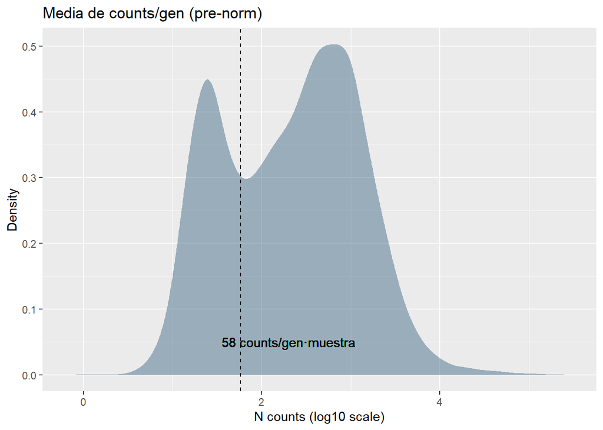

```
## [1] "Número inicial de genes: 19398"
```

```
## [1] "Número de genes despreciados en el pre-filtrado: 5706"
```

```
## [1] "Número de genes que pasan el prefiltrado: 13692"
```

## Normalización

Después del prefiltrado, se procede a realizar la normalización de los datos (mediante la estimación de los factores de tamaño), la estimación de las dispersiones, el ajuste de un modelo lineal y la aplicación de contrastes de hipótesis sobre ese modelo. Todo ello se realiza con la función `DESeq()`.

```r
dds <- DESeq(dds)
```

[output not shown]

[output not shown]

[output not shown]

```
## -- replacing outliers and refitting for 64 genes
## -- DESeq argument 'minReplicatesForReplace' = 7
## -- original counts are preserved in counts(dds)
```

[output not shown]

## Transformación VST

La transformación VST (Variance-Stabilizing Transformation) es una transformación logarítmica que estabiliza la varianza en función de la media y permite la comparación de muestras con diferentes niveles de expresión.

Por limitaciones técnicas, los datos obtenidos de las técnicas de transcriptómica masiva como RNA-seq o, en este caso HTG-seq, tienen una relación de dependencia entre la media y la varianza. Los genes poco expresados (media de counts pequeña) tienen una alta varianza (incrementa el peso del ruido en la secuenciación y la imprecisión genera mucha variabilidad entre réplicas/muestras), mientras que los genes altamente expresados (media de counts grande) tienen una varianza muy pequeña (con muchos contajes para el mismo transcrito, se reduce el peso del ruido e imprecisión y las muestras son fácilmente comparables sin sesgos técnicos).

Transformaciones como VST o rlog hacen más uniforme la variabilidad de los datos, sobretodo en genes con baja expresión. Ambas aplican una transformación logarítmica en base 2 (log2), pero mientras que VST aplica un modelo paramétrico (expresión fija) para la transformación, rlog ajusta un modelo con un término variable en función de cada muestra y además realiza un encogimiento (shrinkage) de los cambios logarítmicos (log fold changes) para cada muestra, reduciendo hacia cero los LFC de muestras con mayor dispersión de datos respecto a su media. En este caso se utiliza VST.

## Análisis de la Variabilidad

Una vez los datos se han pre-filtrado y normalizado, se generan gráficos PCA (1ª vs 2ª componente) para ver como se distribuyen las muestras en función de distintas variables de metadatos.

```
## using ntop=500 top features by variance
```

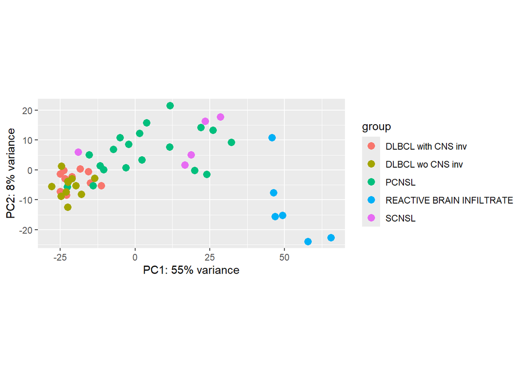

```
## using ntop=500 top features by variance
```

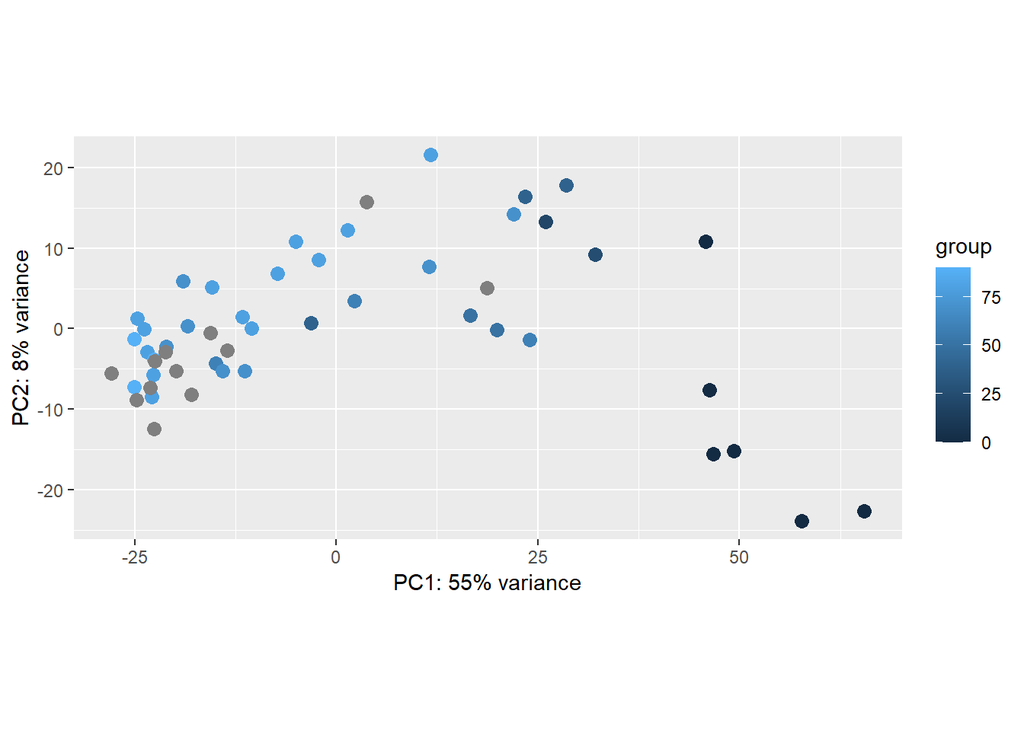

```
## using ntop=500 top features by variance
```

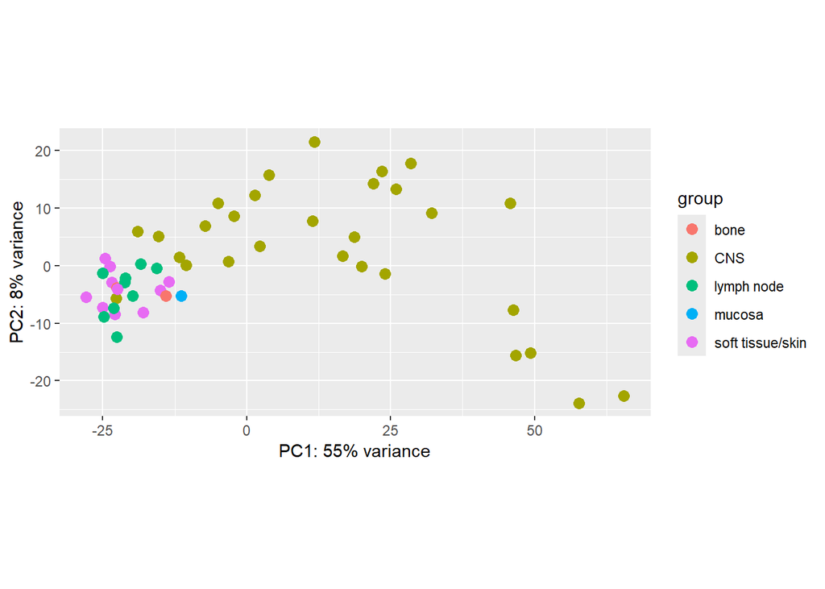

```
## using ntop=500 top features by variance
```

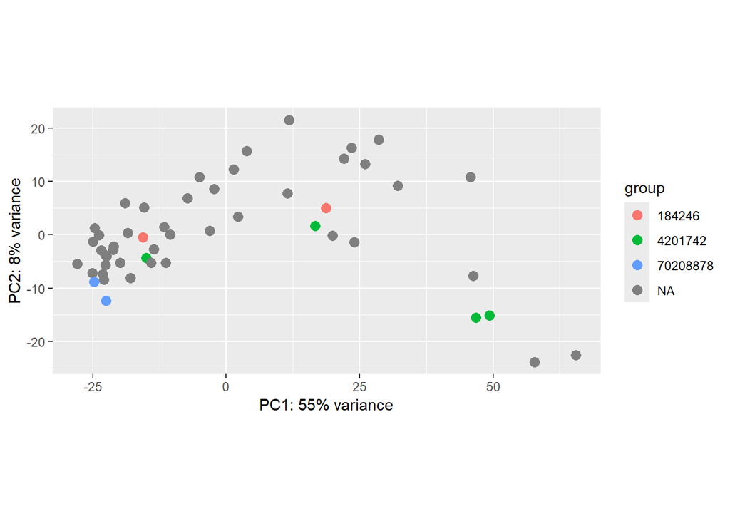

```
## using ntop=500 top features by variance
```

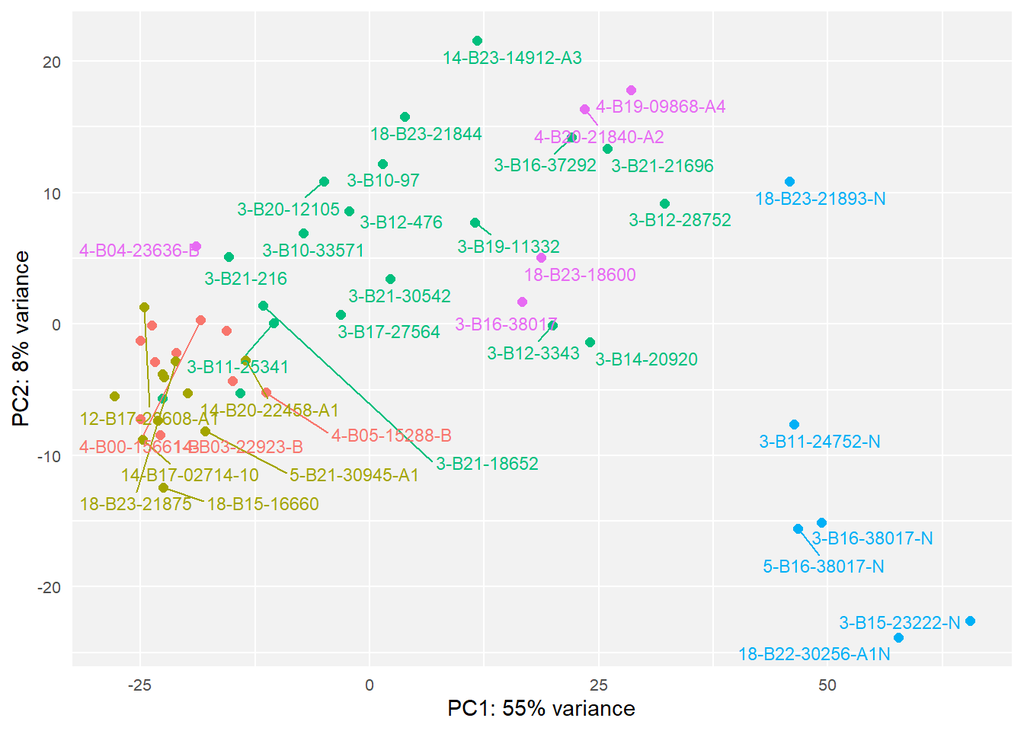

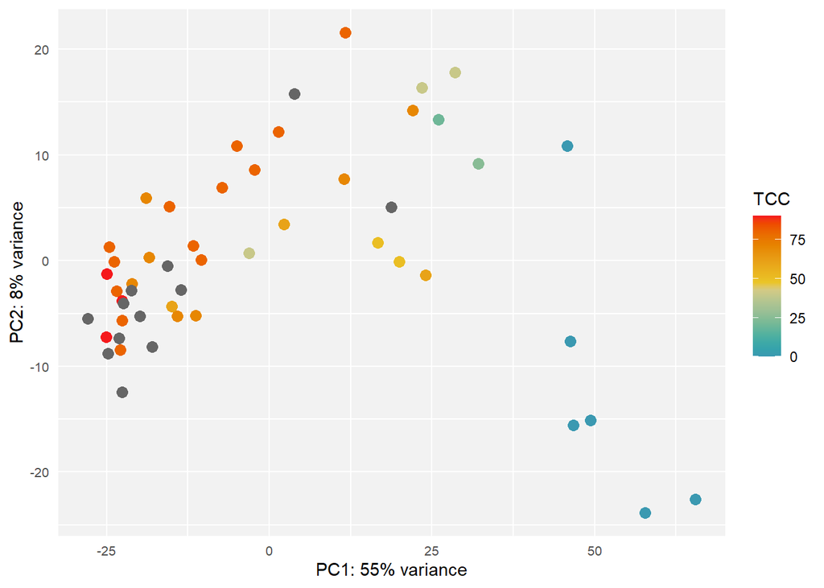

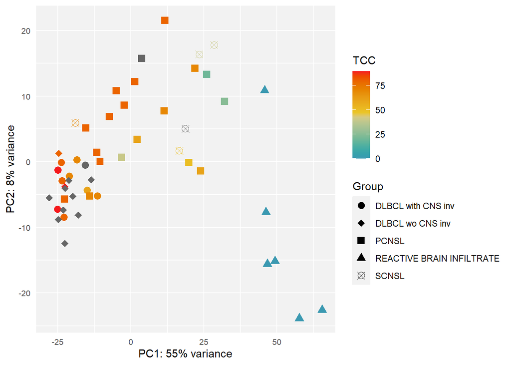

## Distribución de los datos Pre y Post Normalización

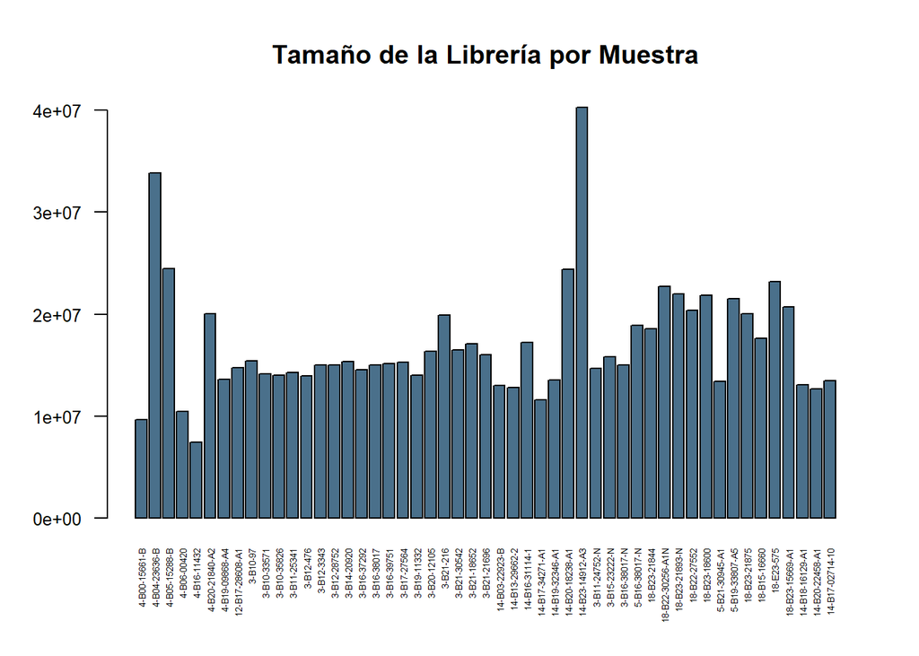

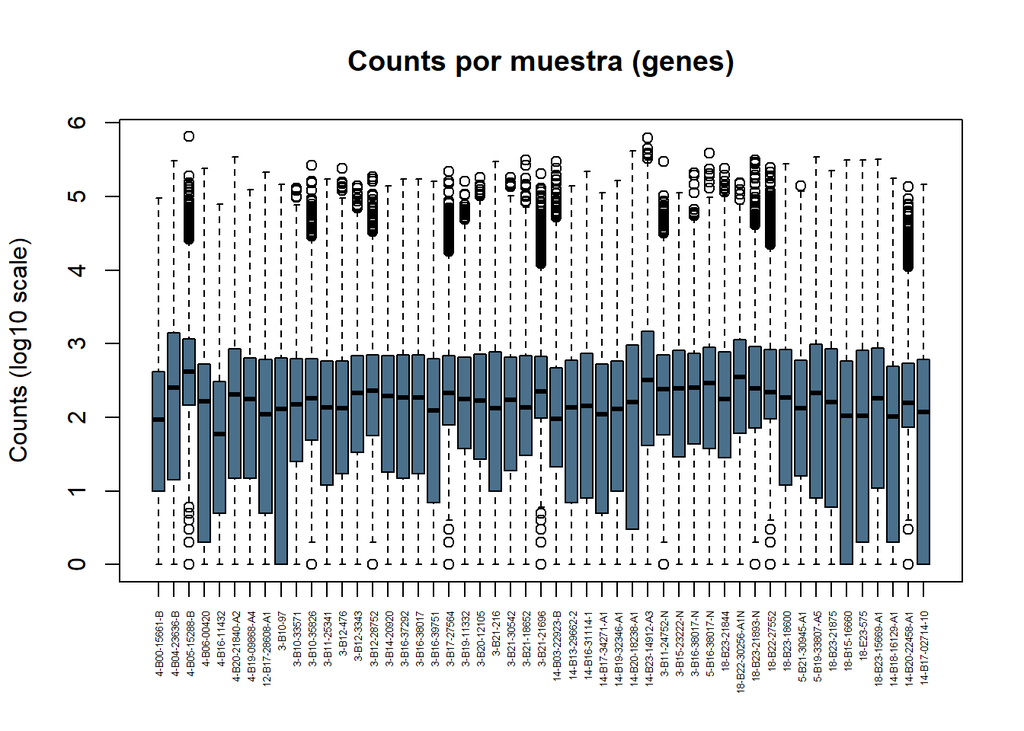

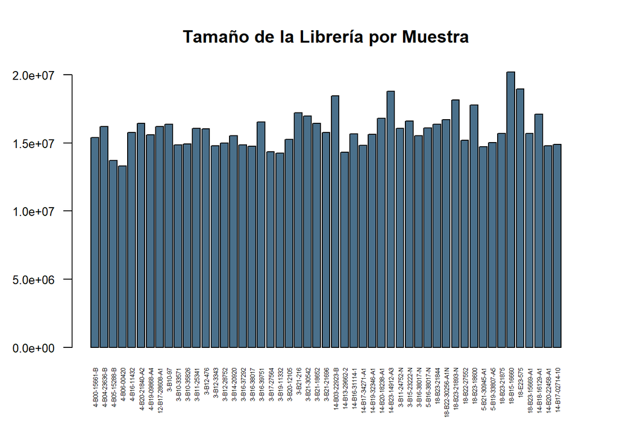

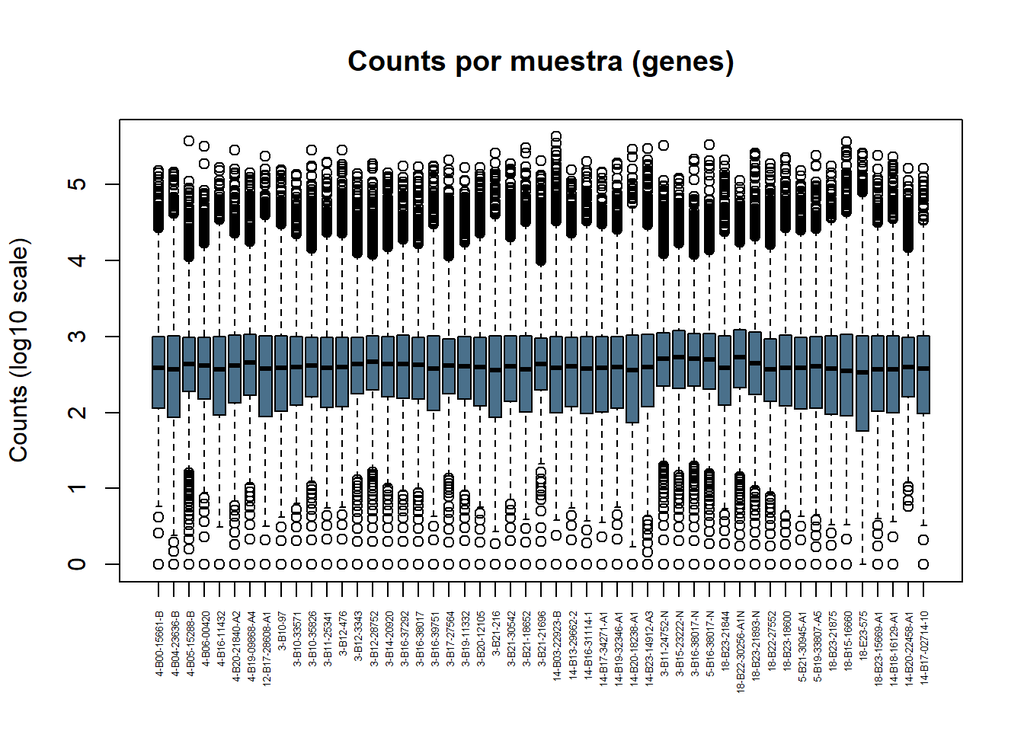

## Genes Diferencialmente Expresados

Con la función `results` se obtiene una tabla en la que se muestra para cada gen, en este caso se representan los genes diferencialmente expresados entre PCNSL y SCNSL mediante la opción `contrast`, especificando el umbral de significancia o `alpha` en 0.05.

```
## log2 fold change (MLE): Group PCNSL vs SCNSL
## Wald test p-value: Group PCNSL vs SCNSL
## DataFrame with 13692 rows and 6 columns
##         baseMean log2FoldChange     lfcSE      stat    pvalue      padj
##        <numeric>      <numeric> <numeric> <numeric> <numeric> <numeric>
## A1BG     57.4047       0.588499  0.593757  0.991144 0.3216154   0.99992
## A2M    3663.7389      -0.451520  0.393680 -1.146922 0.2514138   0.99992
## A4GALT  342.6575       1.603412  0.765687  2.094084 0.0362525   0.99992
## AAAS    933.8131       0.068492  0.185171  0.369886 0.7114676   0.99992
## AACS    702.6181       0.140584  0.376868  0.373032 0.7091245   0.99992
## ...          ...            ...       ...       ...       ...       ...
## ZYG11A   335.922      0.9725254  1.435205  0.677621  0.498012   0.99992
## ZYG11B   756.551     -0.0860684  0.185593 -0.463748  0.642828   0.99992
## ZYX     2521.921      0.1377046  0.363172  0.379171  0.704561   0.99992
## ZZEF1   1344.333     -0.1824943  0.193877 -0.941287  0.346558   0.99992
## ZZZ3    1161.572     -0.1442105  0.184373 -0.782165  0.434118   0.99992
```

```
##
## out of 13692 with nonzero total read count
## adjusted p-value < 0.05
## LFC > 0 (up)       : 23, 0.17%
## LFC < 0 (down)     : 0, 0%
## outliers [1]       : 5, 0.037%
## low counts [2]     : 0, 0%
## (mean count < 5)
## [1] see 'cooksCutoff' argument of ?results
## [2] see 'independentFiltering' argument of ?results
```

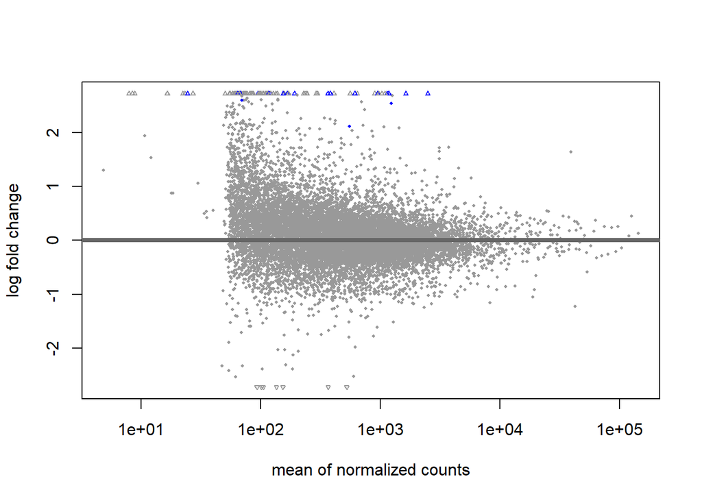

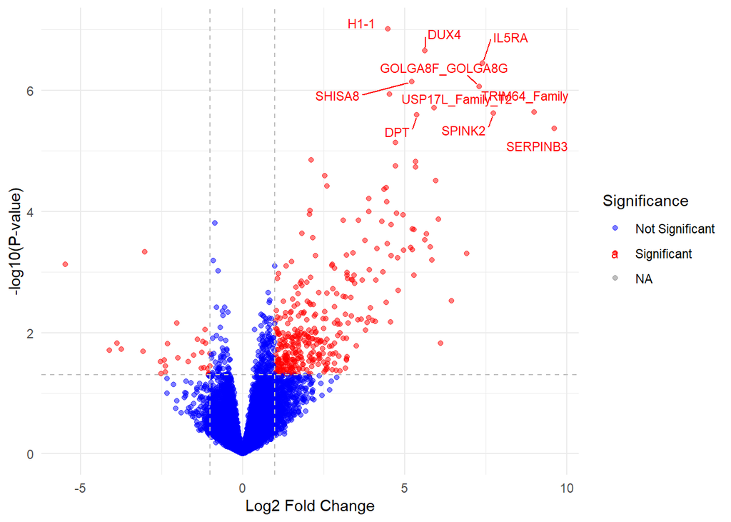

Ahora se genera un selección de los genes diferencialmente expresados, con los criterios de p-valor ajustado inferior a 0.05 y LogFoldChange superior a 1.

```
## log2 fold change (MLE): Group PCNSL vs SCNSL
##
## DataFrame with 23 rows and 2 columns
##                 log2FoldChange       padj
##                      <numeric>  <numeric>
## SERPINB3               9.61191 0.00532300
## TRIM64_Family          9.00028 0.00347811
## SPINK2                 7.73832 0.00347811
## IL5RA                  7.39757 0.00163294
## GOLGA8F_GOLGA8G        7.30521 0.00237539
## ...                        ...        ...
## USP17L10               4.35673  0.0280716
## LTK                    3.88619  0.0378681
## SLC25A53               2.60190  0.0272904
## CD27                   2.54202  0.0208767
## PISD                   2.11226  0.0148106
```

# Comparación PCNSL vs SCNSL

Utilizando como plantilla el anterior pipeline de `DESeq2`, se repetite dicho protocolo pero esta vez, con un subset de los datos en los que únicamente se incluyen las muestras de los grupos PCNSL y SCNSL. Debido a que se generan objetos dds nuevos con cada comparación, se genera un prefiltrado idéntico al utilizado con el set del total de muestras, utilizando la misma selección de genes prefiltrados.

```
## class: DESeqDataSet
## dim: 19398 24
## metadata(1): version
## assays(1): counts
## rownames(19398): A1BG A1CF ... ZZEF1 ZZZ3
## rowData names(0):
## colnames(24): 4-B04-23636-B 4-B20-21840-A2 ... 18-B23-21844
##   18-B23-18600
## colData names(11): tumor cell content tissue_group ... COMMENTS NHC_dup
```

```
## [1] "Número inicial de genes: 19398"
```

```
## [1] "Número de genes despreciados en el pre-filtrado: 5706"
```

```
## [1] "Número de genes que pasan el prefiltrado: 13692"
```

```
## -- replacing outliers and refitting for 151 genes
## -- DESeq argument 'minReplicatesForReplace' = 7
## -- original counts are preserved in counts(dds)
```

```
## using ntop=500 top features by variance
```

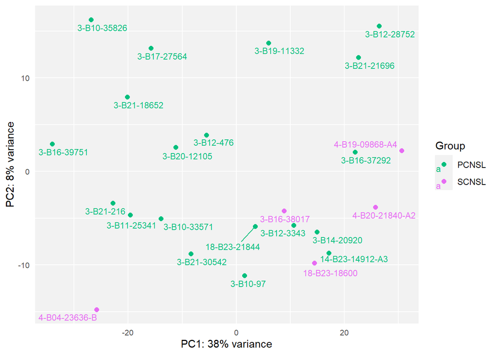

## Clustering No Supervisado

Se utilizan las opciones de clustering predeterminadas del paquete pheatmap(), utilizando el método de agrupamiento jerárquico completo y la distancia euclidiana, en todas las representaciones.

```
## [1] TRUE
```

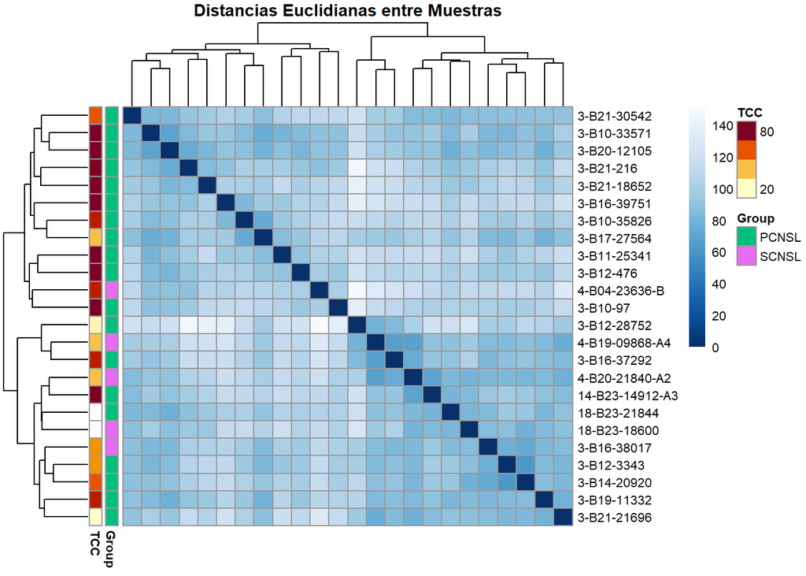

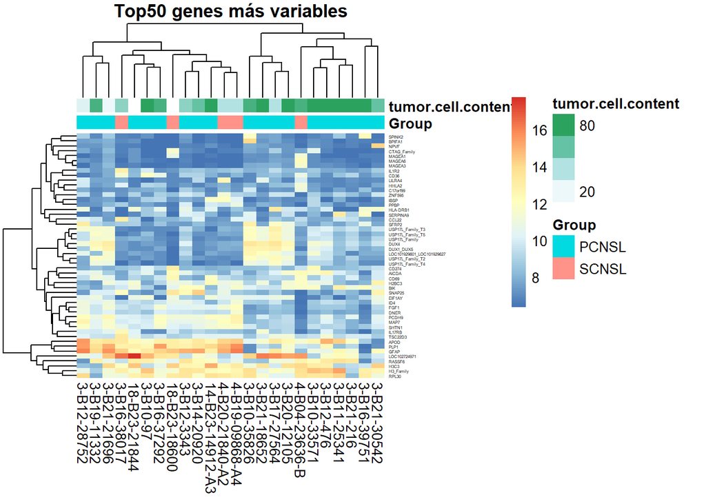

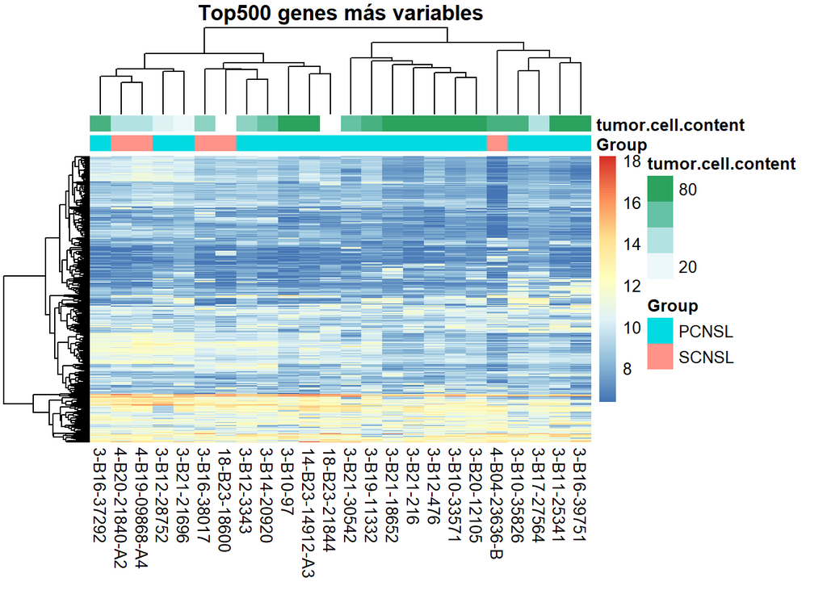

```
## log2 fold change (MLE): Group PCNSL vs SCNSL
## Wald test p-value: Group PCNSL vs SCNSL
## DataFrame with 13692 rows and 6 columns
##         baseMean log2FoldChange     lfcSE      stat    pvalue      padj
##        <numeric>      <numeric> <numeric> <numeric> <numeric> <numeric>
## A1BG     55.5198      0.5833848  0.545418  1.069610 0.2847949  0.972353
## A2M    4499.9577     -0.4592052  0.379342 -1.210529 0.2260758  0.972353
## A4GALT  243.1201      1.6149309  0.757689  2.131391 0.0330569  0.731418
## AAAS   1021.6884      0.0582256  0.197941  0.294157 0.7686378  0.994162
## AACS    571.0292      0.1407139  0.280852  0.501025 0.6163534  0.985510
## ...          ...            ...       ...       ...       ...       ...
## ZYG11A   342.495      1.0019691  1.157734  0.865457  0.386788  0.972353
## ZYG11B   684.046     -0.0825737  0.176782 -0.467094  0.640432  0.986619
## ZYX     2564.230      0.1357793  0.328147  0.413776  0.679038  0.989472
## ZZEF1   1239.557     -0.1813554  0.157033 -1.154889  0.248136  0.972353
## ZZZ3    1123.028     -0.1475738  0.206294 -0.715358  0.474388  0.972353
```

```
##
## out of 13692 with nonzero total read count
## adjusted p-value < 0.05
## LFC > 0 (up)       : 64, 0.47%
## LFC < 0 (down)     : 1, 0.0073%
## outliers [1]       : 49, 0.36%
## low counts [2]     : 0, 0%
## (mean count < 8)
## [1] see 'cooksCutoff' argument of ?results
## [2] see 'independentFiltering' argument of ?results
```

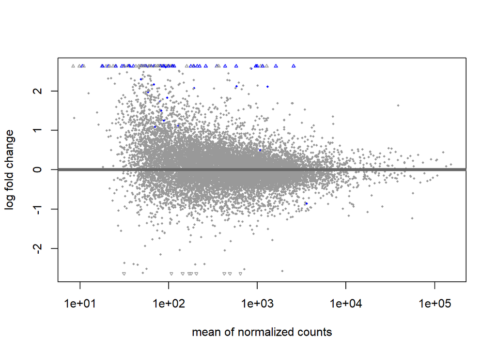

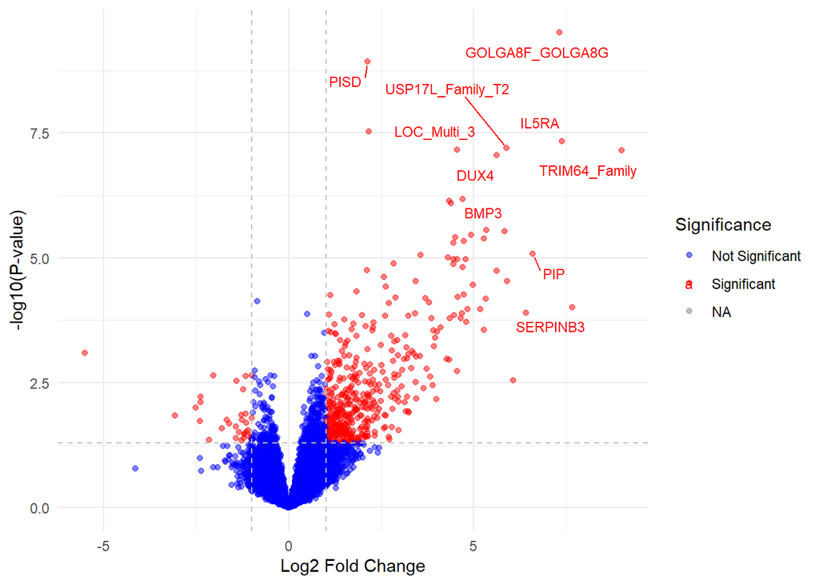

Se representan los 10 primeros genes de la selección de genes diferencialmente expresados entre PCNSL vs SCNSL, con un p-valor ajustado inferior a 0.1 y un baseMean superior a 100.

```
## log2 fold change (MLE): Group PCNSL vs SCNSL
## Wald test p-value: Group PCNSL vs SCNSL
## DataFrame with 10 rows and 6 columns
##            baseMean log2FoldChange     lfcSE      stat      pvalue       padj
##           <numeric>      <numeric> <numeric> <numeric>   <numeric>  <numeric>
## ABCC6       109.826        2.87953  0.719043   4.00468 6.21026e-05 0.02156945
## BCAS4       696.194        1.53526  0.441405   3.47812 5.04948e-04 0.08010472
## CD247       487.061        2.27037  0.619612   3.66417 2.48138e-04 0.05052753
## CD27        858.234        2.56861  0.608504   4.22118 2.43024e-05 0.01105192
## COL15A1     193.546        2.07301  0.563450   3.67913 2.34030e-04 0.04912116
## CRNDE       107.521        2.85705  0.816107   3.50083 4.63815e-04 0.07444505
## CYS1        131.498        2.48908  0.720332   3.45546 5.49355e-04 0.08614772
## DUX1_DUX5  1615.904        5.34051  1.139822   4.68539 2.79427e-06 0.00310346
## DUX4       2555.979        5.62137  1.050977   5.34871 8.85849e-08 0.00015107
## FKBP14      366.257        1.13691  0.315064   3.60849 3.07980e-04 0.05678062
```

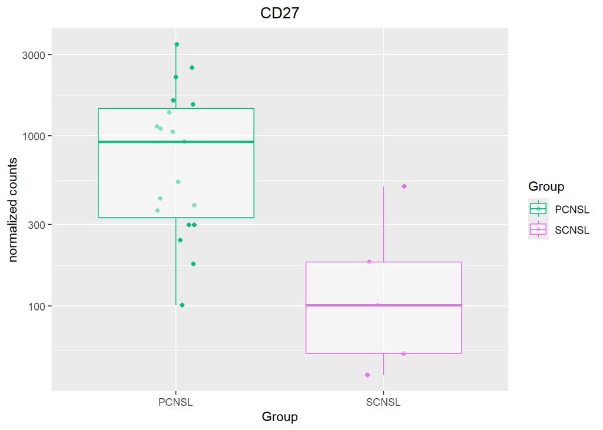

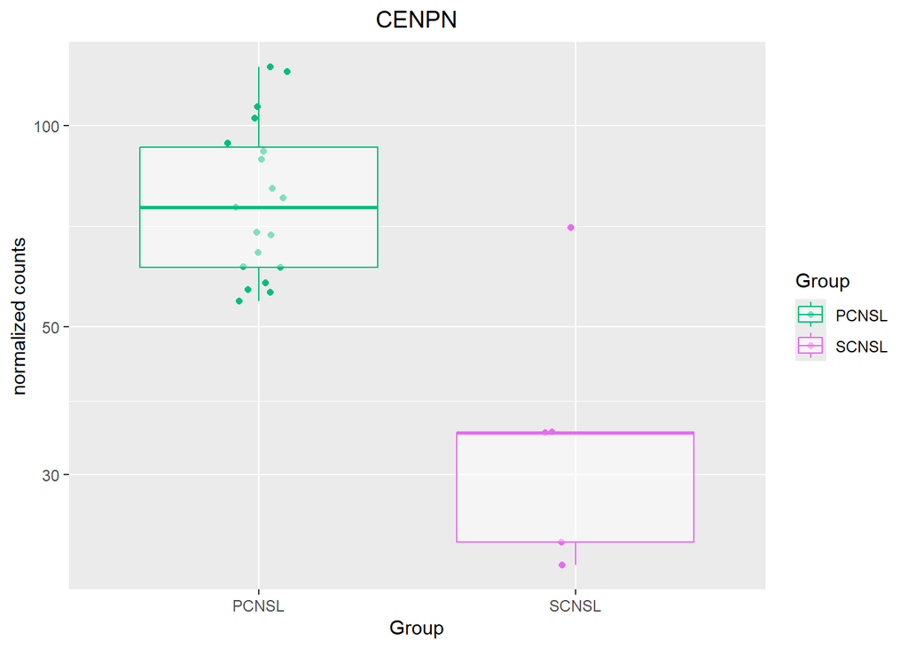

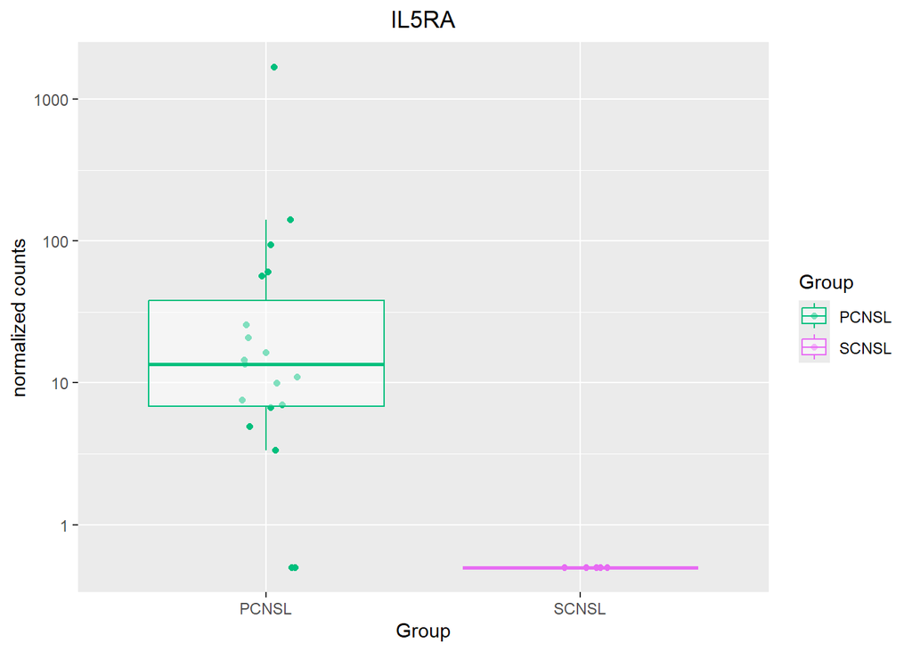

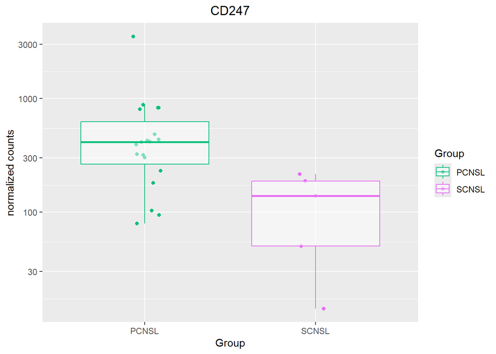

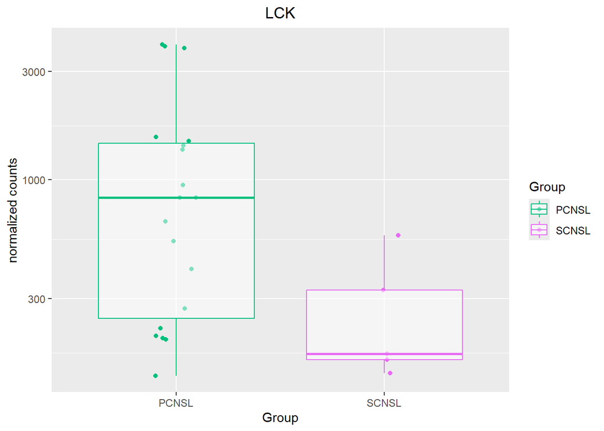

# **Comparación DLBCL with vs wo CNS inv**

```
##   Note: levels of factors in the design contain characters other than
##   letters, numbers, '_' and '.'. It is recommended (but not required) to use
##   only letters, numbers, and delimiters '_' or '.', as these are safe characters
##   for column names in R. [This is a message, not a warning or an error]
```

```
## class: DESeqDataSet
## dim: 19398 21
## metadata(1): version
## assays(1): counts
## rownames(19398): A1BG A1CF ... ZZEF1 ZZZ3
## rowData names(0):
## colnames(21): 4-B00-15661-B 4-B05-15288-B ... 14-B20-22458-A1
##   14-B17-02714-10
## colData names(11): tumor cell content tissue_group ... COMMENTS NHC_dup
```

```
## [1] "Número inicial de genes: 19398"
```

```
## [1] "Número de genes despreciados en el pre-filtrado: 5706"
```

```
## [1] "Número de genes que pasan el prefiltrado: 13692"
```

[output not shown]

[output not shown]

[output not shown]

```
## -- replacing outliers and refitting for 463 genes
## -- DESeq argument 'minReplicatesForReplace' = 7
## -- original counts are preserved in counts(dds)
```

[output not shown]

```
## using ntop=500 top features by variance
```

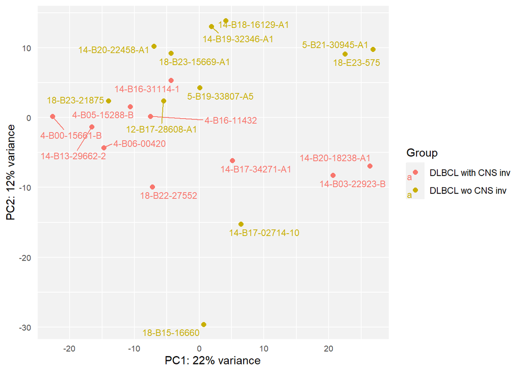

## Clustering No Supervisado

Se utilizan las opciones de clustering predeterminadas del paquete pheatmap(), utilizando el método de agrupamiento jerárquico completo y la distancia euclidiana, en todas las representaciones.

```
## [1] TRUE
```

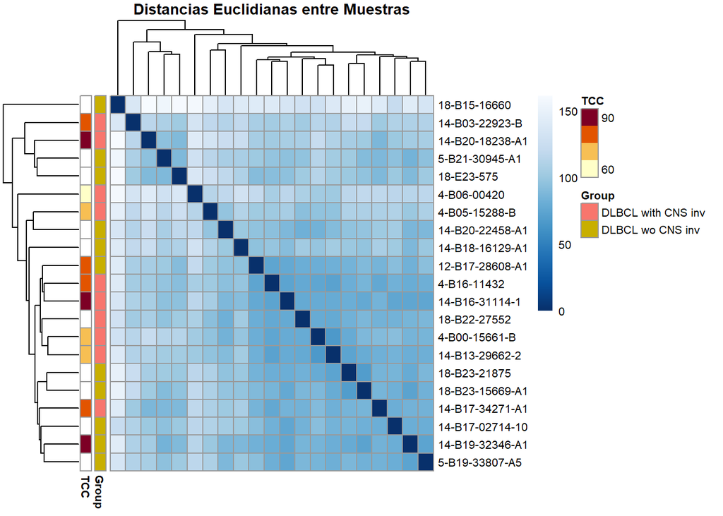

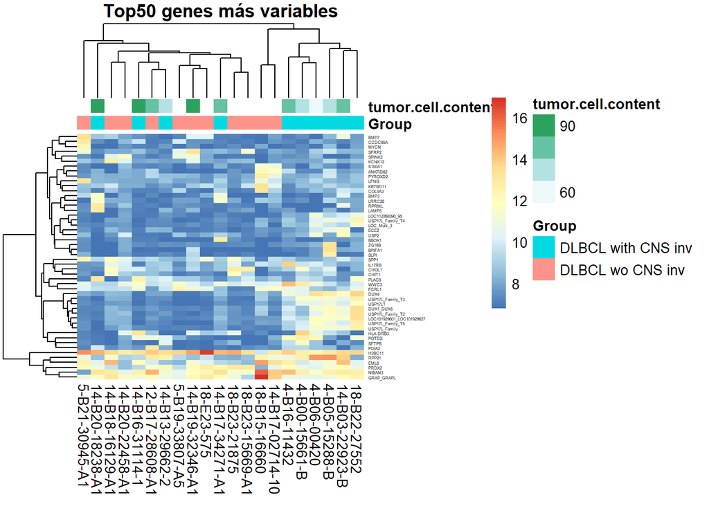

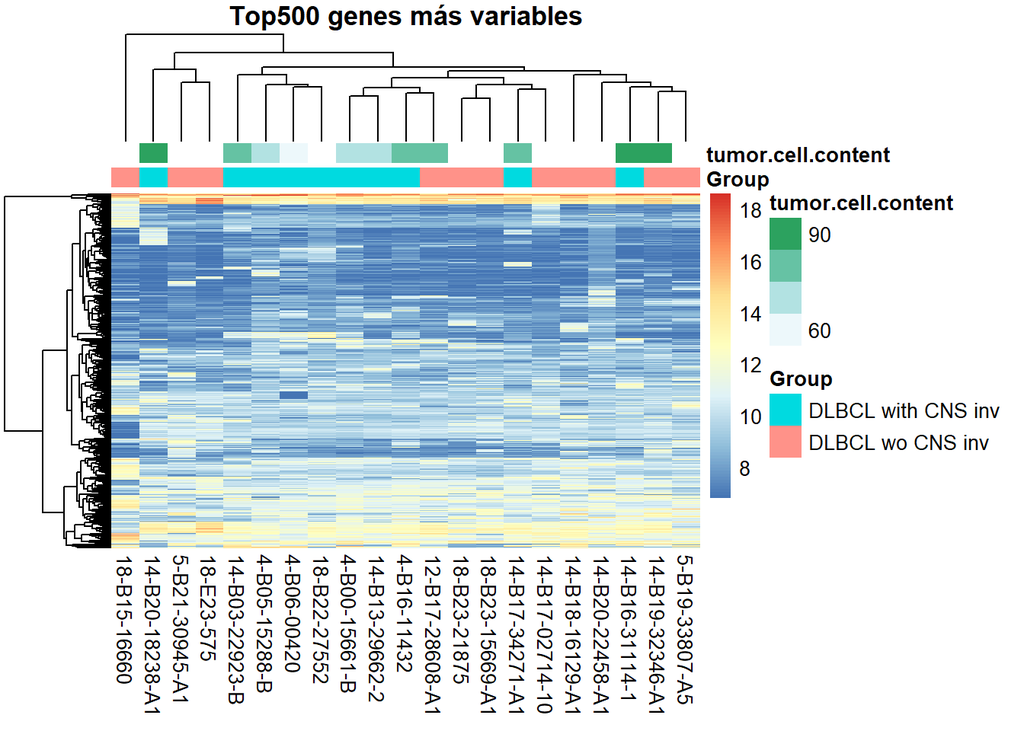

```
## log2 fold change (MLE): Group DLBCL with CNS inv vs DLBCL wo CNS inv
## Wald test p-value: Group DLBCL with CNS inv vs DLBCL wo CNS inv
## DataFrame with 13692 rows and 6 columns
##         baseMean log2FoldChange     lfcSE       stat    pvalue      padj
##        <numeric>      <numeric> <numeric>  <numeric> <numeric> <numeric>
## A1BG     51.1955     0.86244107  0.612957  1.4070177  0.159422        NA
## A2M    1614.3021    -0.21943141  0.354849 -0.6183792  0.536325  0.905662
## A4GALT  474.3652    -1.11280287  0.683572 -1.6279229  0.103541  0.633224
## AAAS    890.2060    -0.00835969  0.185636 -0.0450328  0.964081  0.996863
## AACS    700.9386    -0.00783894  0.385649 -0.0203266  0.983783  0.998554
## ...          ...            ...       ...        ...       ...       ...
## ZYG11A   384.268     -0.6550295  1.456145  -0.449838  0.652827  0.934046
## ZYG11B   638.271      0.0977682  0.205399   0.475991  0.634081  0.929875
## ZYX     2283.861      0.0785933  0.371472   0.211572  0.832441  0.978691
## ZZEF1   1400.954      0.1692802  0.206807   0.818543  0.413047  0.869524
## ZZZ3    1188.469      0.1821645  0.184795   0.985765  0.324248  0.828533
```

```
##
## out of 13692 with nonzero total read count
## adjusted p-value < 0.05
## LFC > 0 (up)       : 19, 0.14%
## LFC < 0 (down)     : 3, 0.022%
## outliers [1]       : 0, 0%
## low counts [2]     : 1328, 9.7%
## (mean count < 53)
## [1] see 'cooksCutoff' argument of ?results
## [2] see 'independentFiltering' argument of ?results
```

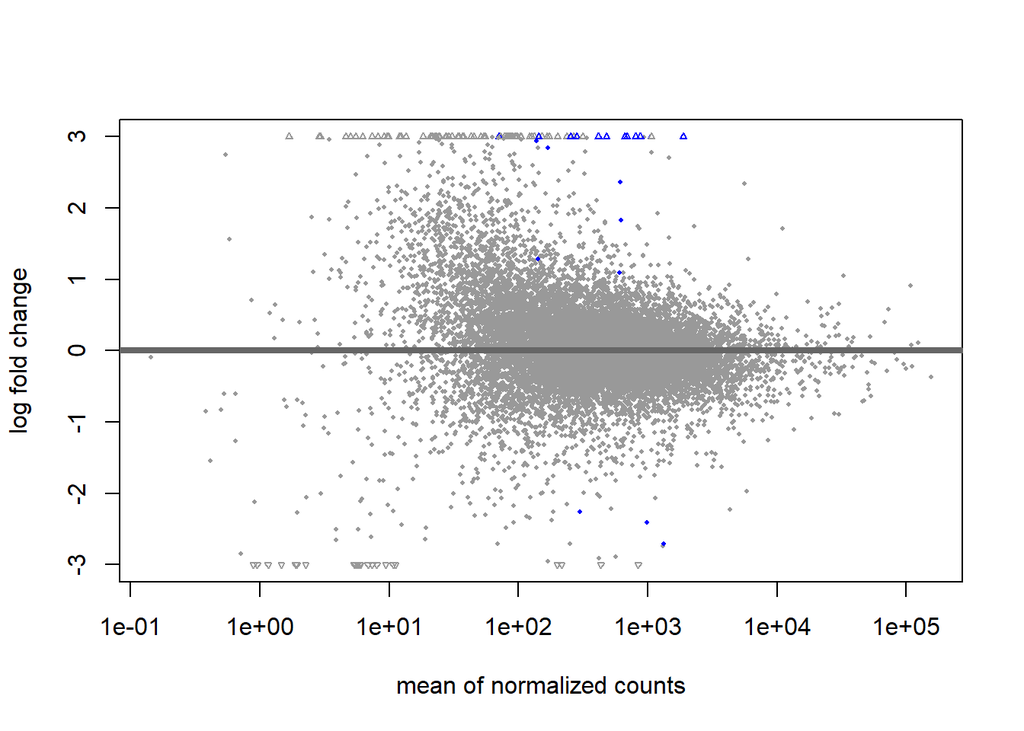

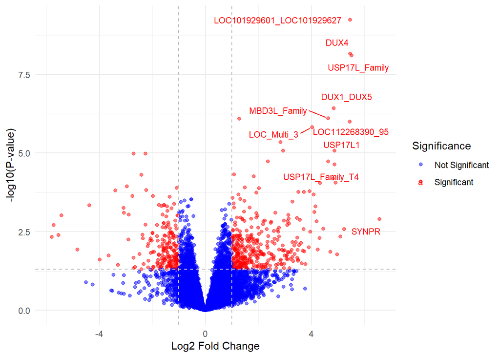

```
## log2 fold change (MLE): Group DLBCL with CNS inv vs DLBCL wo CNS inv
## Wald test p-value: Group DLBCL with CNS inv vs DLBCL wo CNS inv
## DataFrame with 10 rows and 6 columns
##                baseMean log2FoldChange     lfcSE      stat      pvalue
##               <numeric>      <numeric> <numeric> <numeric>   <numeric>
## APLP2          1670.956      -1.074925  0.280563  -3.83131 1.27464e-04
## C15orf48        168.865      -2.957677  0.767237  -3.85497 1.15743e-04
## CLPTM1          775.426      -0.535269  0.148008  -3.61648 2.98636e-04
## COMP            214.734      -3.387873  0.895102  -3.78490 1.53769e-04
## DUX1_DUX5      1072.039       4.843805  0.953293   5.08113 3.75195e-07
## DUX4           1890.906       5.466245  0.943824   5.79160 6.97210e-09
## ELOA3           132.872       4.093323  1.103061   3.71088 2.06543e-04
## FN1            4333.055      -2.230456  0.588673  -3.78895 1.51282e-04
## FXYD2           137.957       2.936826  0.658903   4.45714 8.30589e-06
## GAGE_Family_2   236.798       3.517923  0.935718   3.75960 1.70186e-04
##                      padj
##                 <numeric>
## APLP2         6.14962e-02
## C15orf48      6.14962e-02
## CLPTM1        9.00568e-02
## COMP          6.78998e-02
## DUX1_DUX5     1.15973e-03
## DUX4          3.21256e-05
## ELOA3         7.58167e-02
## FN1           6.78998e-02
## FXYD2         9.50107e-03
## GAGE_Family_2 6.86197e-02
```